# Scenarios Analyses

2025-05-22

## 1. Overview of scenario data

First, I look at how participants rated the appropriateness of each violation in each scenario, and the appropriateness of the different types of punishments in that scenario.

Data is displayed separately by treatment, i.e. whether the violation is done by a **friend/non-friend**, and weather the punishment is performed by a friend to a **friend/non-friend**. Treatments are between subjects.

**Insights:**  
All violations are considered fairly inappropriate, with insulting a family member and stealing being the worst.  
There is quite some variation in appropriateness of the different types of punishment.  
There are no striking differences between treatments.

### Stealing

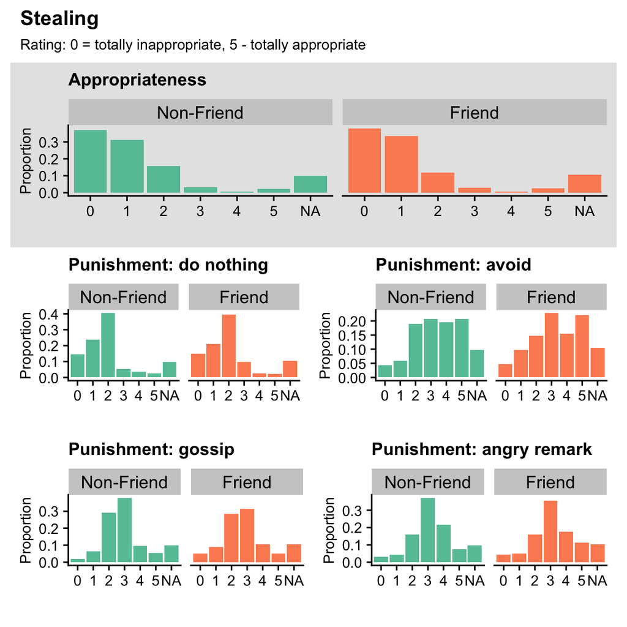

### Phone

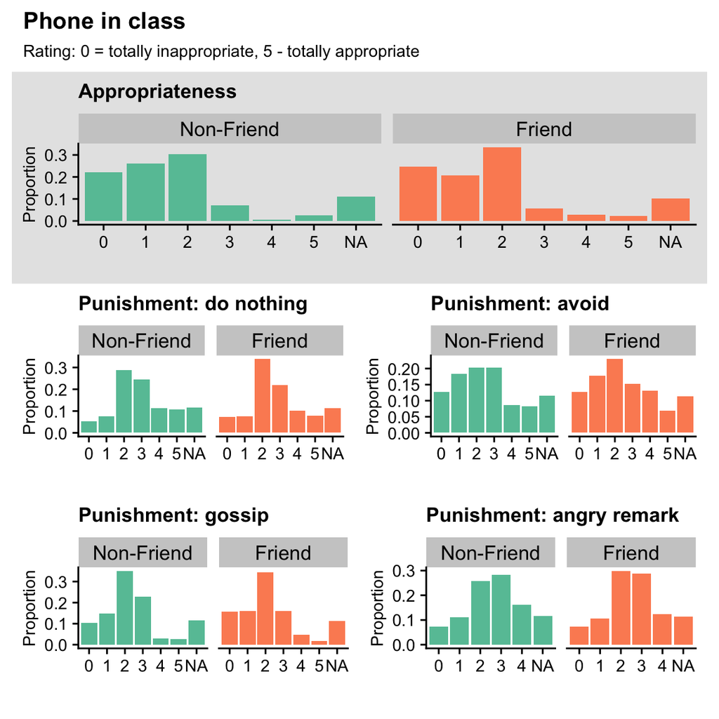

### Interrupt

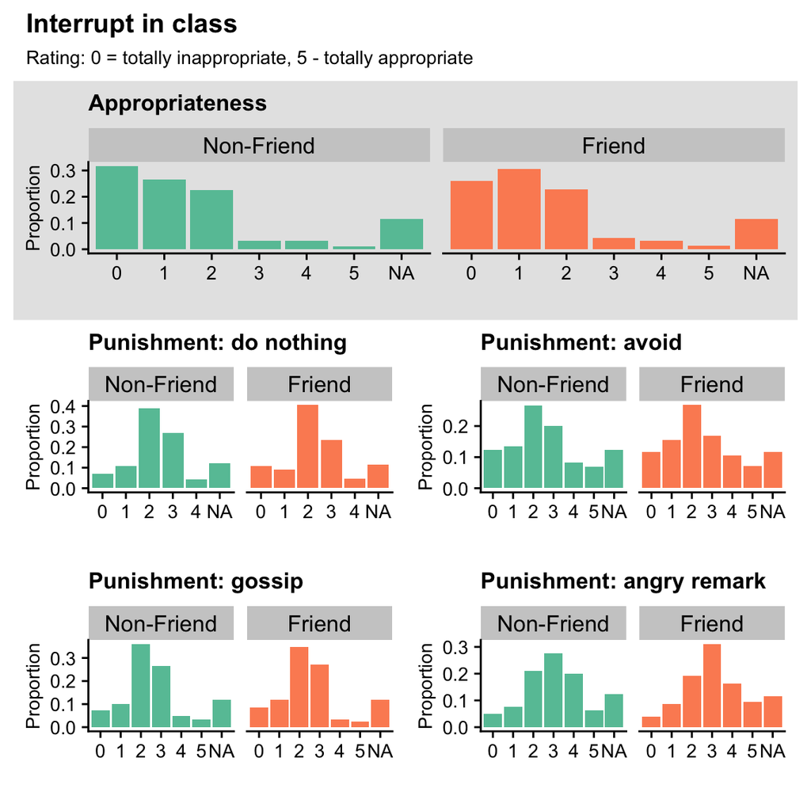

### Insult

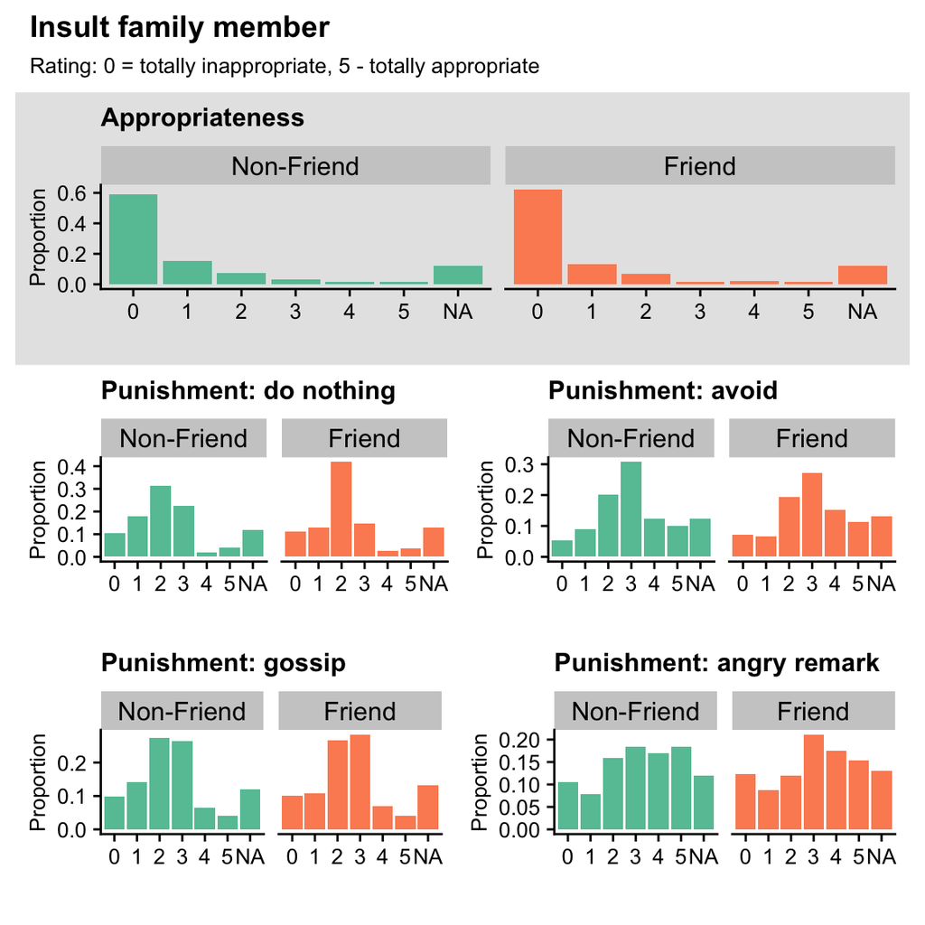

### Exclude

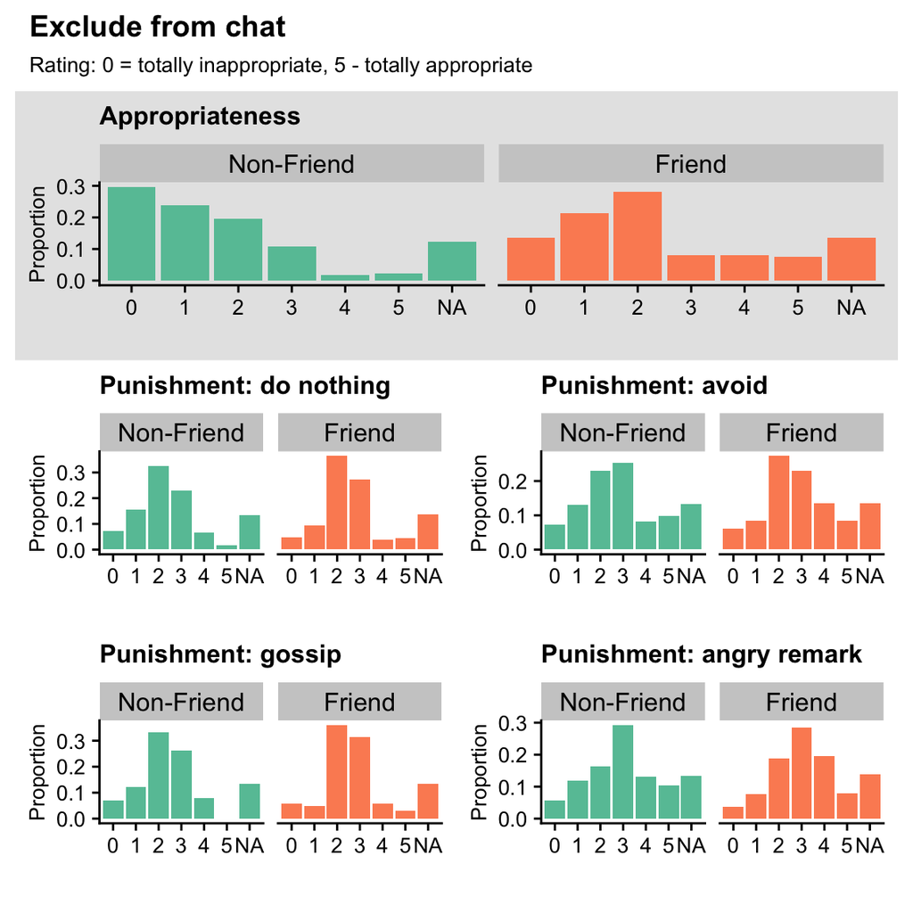

## 2. Analysis of appropriateness of violations across all domains

Now I merge all the scenarios together.

**Insight:**

Overall appropriateness is quite low, with again no striking difference between treatments.

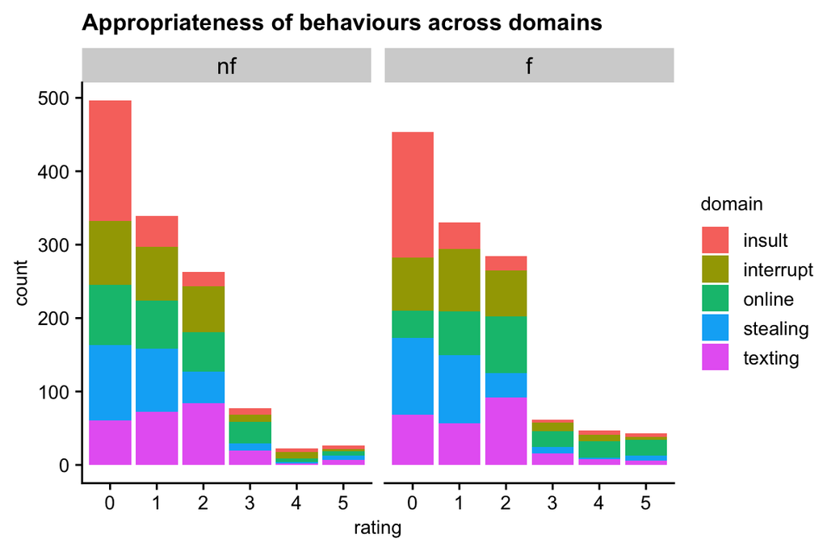

## 2.1 ANOVA

First I run an ANOVA to get an idea of differences across treatments and domains. The ANOVA showed that both treatment and domain significantly affected ratings, with a significant interaction indicating that the effect of treatment varied across domains.

```
##                    Df Sum Sq Mean Sq F value   Pr(>F)
## treatment           1     12   12.50   9.080  0.00261 **
## domain              4    324   80.97  58.817  < 2e-16 ***
## treatment:domain    4     47   11.71   8.507 8.16e-07 ***
## Residuals        2433   3349    1.38
## ---
## Signif. codes:  0 '***' 0.001 '**' 0.01 '*' 0.05 '.' 0.1 ' ' 1
```

## 2.2 Regressions

I now run two multilevel linear regressions with participants as random intercept to zoom in on size and direction of efffects.

First, a linear regression predicting rating ~ treatment shows a small effect of treatment: violations by friends are considered slightly more appropriate.

If we include a test of interactions between treatment and domain, we can see that the effect is driven by the “exclude from online chat scenario:

> “One student who is part of your **friends/others** **group** (**Student A**) excluded **another student**, who is also a part of your **friends group**, from a group chat on WhatsApp.”

### Rating ~ Treatment

|  | rating |  |  |
| --- | --- | --- | --- |
| Predictors | Estimates | CI | p |
| (Intercept) | 1.08 | 1.00 – 1.16 | **<0.001** |
| treatmentf | 0.14 | 0.05 – 0.23 | **0.003** |
| Random Effects |  |  |  |
| σ<sup>2</sup> | 1.26 |  |  |
| τ<sub>00</sub> <sub>ID2</sub> | 0.27 |  |  |
| ICC | 0.18 |  |  |
| N <sub>ID2</sub> | 496 |  |  |
| Observations | 2443 |  |  |
| Marginal R<sup>2</sup> / Conditional R<sup>2</sup> | 0.003 / 0.178 |  |  |

### Rating ~ Treatment * Domain

|  | rating |  |  |
| --- | --- | --- | --- |
| Predictors | Estimates | CI | p |
| (Intercept) | 0.61 | 0.46 – 0.75 | **<0.001** |
| treatmentf | -0.04 | -0.25 – 0.17 | 0.721 |
| domain interrupt | 0.53 | 0.32 – 0.74 | **<0.001** |
| domain [online] | 0.68 | 0.50 – 0.87 | **<0.001** |
| domain stealing | 0.35 | 0.14 – 0.56 | **0.001** |
| domain [texting] | 0.79 | 0.60 – 0.97 | **<0.001** |
| treatmentf × domain interrupt | 0.13 | -0.19 – 0.46 | 0.421 |
| treatmentf × domain [online] | 0.74 | 0.48 – 1.00 | **<0.001** |
| treatmentf × domain stealing | -0.01 | -0.33 – 0.32 | 0.970 |
| treatmentf × domain [texting] | 0.07 | -0.19 – 0.33 | 0.602 |
| Random Effects |  |  |  |
| σ<sup>2</sup> | 1.07 |  |  |
| τ<sub>00</sub> <sub>ID2</sub> | 0.31 |  |  |
| ICC | 0.22 |  |  |
| N <sub>ID2</sub> | 496 |  |  |
| Observations | 2443 |  |  |
| Marginal R<sup>2</sup> / Conditional R<sup>2</sup> | 0.103 / 0.301 |  |  |

## 3. Analysis of appropriateness of punishment if friend vs. non-friend

Now I look at the appropriateness ratings of punishments if the violator is a friend vs. non friend.

## 3.1 Vizualization

Again, visual inspection does not reveal any striking differences bewteen treatments and domains.

### Overall appropriatess across domains

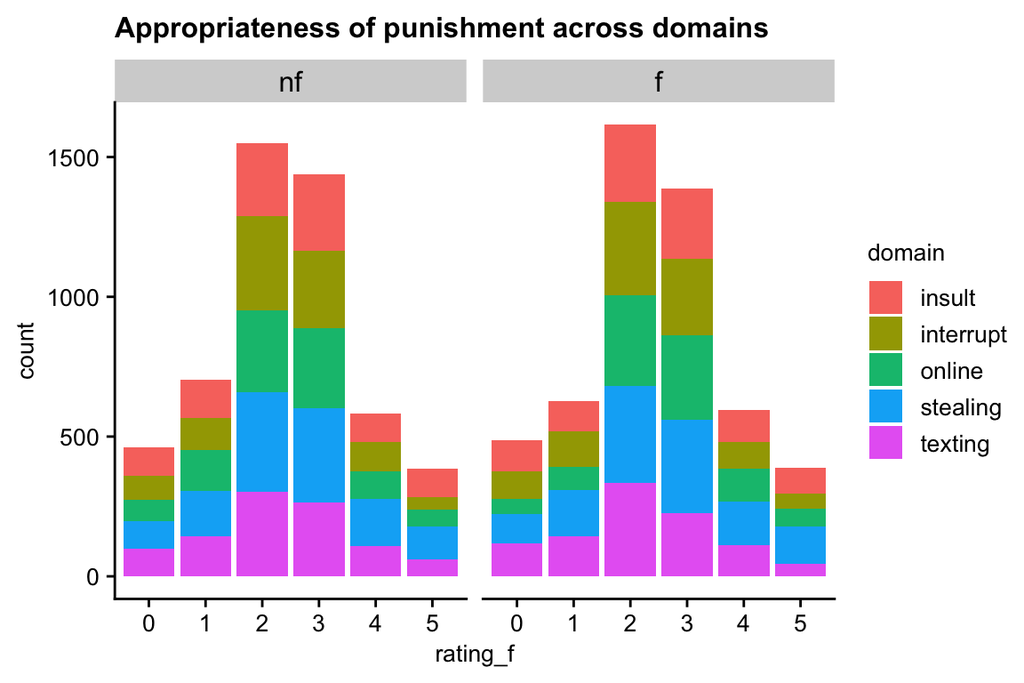

### Appropriateness by domain

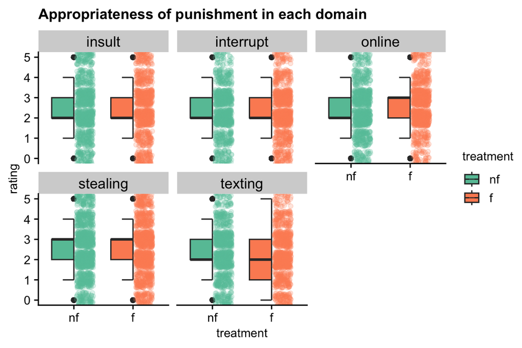

### Appropriateness of punishment by treatment and punisment type

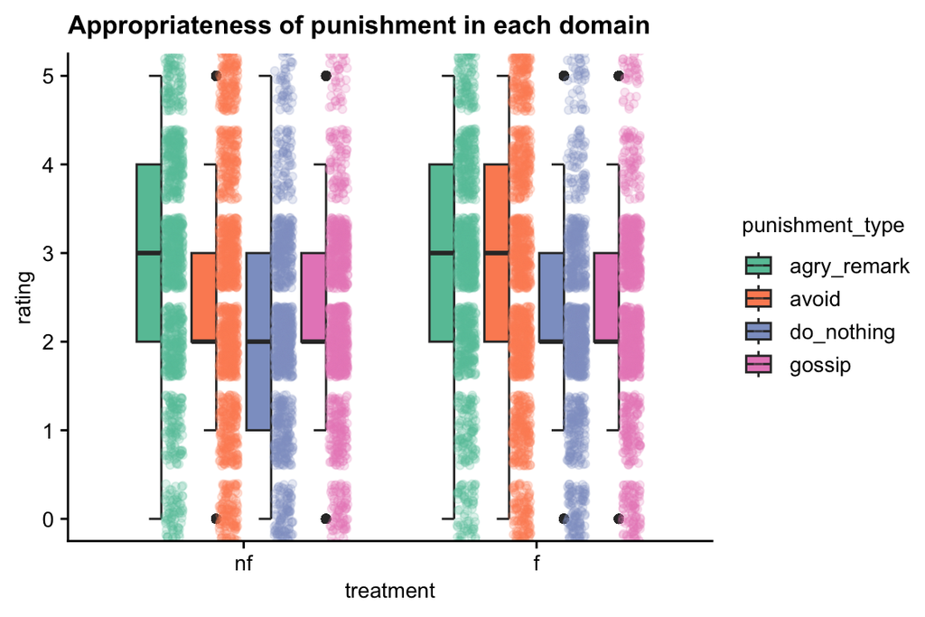

## 3.1 ANOVA

First, I run an ANOVA to get an idea of differences in mean ratings across treatments and domains.

There was **no significant main effect of treatment**.

In contrast, **domain** was significant, suggesting that the ratings varied meaningfully across different domains.

The interaction between **treatment and domain** was also significant, implying that the effect of treatment differed depending on the domain.

```
##                     Df Sum Sq Mean Sq F value  Pr(>F)
## treatment            1      0   0.033   0.019  0.8903
## domain               4    104  26.028  15.008 3.1e-12 ***
## treatment:domain     4     22   5.472   3.155  0.0133 *
## Residuals        10210  17707   1.734
## ---
## Signif. codes:  0 '***' 0.001 '**' 0.01 '*' 0.05 '.' 0.1 ' ' 1
```

## 3.2 Regressions

Now I fit 3 linear regressions to better explore directions of effects.

First, only with treatment as independent variable, then I add interactions with domain (insult as reference) and finally I also include punishment type as exploratory variable (angry_remark as reference).

The main results are [see tabs below for full results]:

**Model 1: no effect**

**Model2 :**

- Raters considered more appropriate to punish friends who exclude others from group chats.

**Model 3:**

- The domain “texting” was associated with significantly lower ratings compared to the reference domain.
- The punishment types “do nothing” and “gossip” led to significantly lower ratings compared to the reference punishment type.

### Rating ~ Treatment

|  | rating |  |  |
| --- | --- | --- | --- |
| Predictors | Estimates | CI | p |
| (Intercept) | 2.42 | 2.37 – 2.46 | **<0.001** |
| treatmentf | 0.00 | -0.05 – 0.05 | 0.932 |
| Random Effects |  |  |  |
| σ<sup>2</sup> | 1.61 |  |  |
| τ<sub>00</sub> <sub>ID2</sub> | 0.14 |  |  |
| ICC | 0.08 |  |  |
| N <sub>ID2</sub> | 496 |  |  |
| Observations | 10220 |  |  |
| Marginal R<sup>2</sup> / Conditional R<sup>2</sup> | 0.000 / 0.081 |  |  |

### Rating ~ Treatment * Domain

|  | rating |  |  |
| --- | --- | --- | --- |
| Predictors | Estimates | CI | p |
| (Intercept) | 2.45 | 2.36 – 2.55 | **<0.001** |
| treatmentf | -0.01 | -0.14 – 0.12 | 0.916 |
| domain interrupt | -0.11 | -0.24 – 0.02 | 0.089 |
| domain [online] | -0.07 | -0.18 – 0.04 | 0.231 |
| domain stealing | 0.08 | -0.04 – 0.21 | 0.193 |
| domain [texting] | -0.13 | -0.24 – -0.02 | **0.023** |
| treatmentf × domain interrupt | -0.02 | -0.23 – 0.18 | 0.820 |
| treatmentf × domain [online] | 0.18 | 0.02 – 0.34 | **0.024** |
| treatmentf × domain stealing | 0.00 | -0.20 – 0.21 | 0.963 |
| treatmentf × domain [texting] | -0.10 | -0.26 – 0.05 | 0.199 |
| Random Effects |  |  |  |
| σ<sup>2</sup> | 1.59 |  |  |
| τ<sub>00</sub> <sub>ID2</sub> | 0.14 |  |  |
| ICC | 0.08 |  |  |
| N <sub>ID2</sub> | 496 |  |  |
| Observations | 10220 |  |  |
| Marginal R<sup>2</sup> / Conditional R<sup>2</sup> | 0.007 / 0.088 |  |  |

### Rating ~ Treatment * Domain* punishment type

|  | rating |  |  |
| --- | --- | --- | --- |
| Predictors | Estimates | CI | p |
| (Intercept) | 2.89 | 2.73 – 3.05 | **<0.001** |
| treatmentf | -0.11 | -0.34 – 0.12 | 0.353 |
| domain interrupt | -0.11 | -0.34 – 0.12 | 0.343 |
| domain [online] | -0.16 | -0.38 – 0.05 | 0.136 |
| domain stealing | 0.14 | -0.09 – 0.36 | 0.232 |
| domain [texting] | -0.50 | -0.71 – -0.28 | **<0.001** |
| punishment type [avoid] | -0.15 | -0.36 – 0.07 | 0.182 |
| punishment type [do_nothing] | -0.91 | -1.12 – -0.69 | **<0.001** |
| punishment type [gossip] | -0.69 | -0.91 – -0.48 | **<0.001** |
| treatmentf × domain interrupt | 0.17 | -0.16 – 0.51 | 0.309 |
| treatmentf × domain [online] | 0.27 | -0.04 – 0.58 | 0.088 |
| treatmentf × domain stealing | 0.09 | -0.24 – 0.43 | 0.590 |
| treatmentf × domain [texting] | 0.04 | -0.27 – 0.34 | 0.822 |
| treatmentf × punishment type [avoid] | 0.17 | -0.13 – 0.48 | 0.271 |
| treatmentf × punishment type [do_nothing] | 0.06 | -0.25 – 0.37 | 0.699 |
| treatmentf × punishment type [gossip] | 0.17 | -0.14 – 0.48 | 0.278 |
| domain interrupt × punishment type [avoid] | -0.41 | -0.72 – -0.11 | **0.008** |
| domain [online] × punishment type [avoid] | -0.08 | -0.38 – 0.23 | 0.618 |
| domain stealing × punishment type [avoid] | -0.22 | -0.50 – 0.06 | 0.129 |
| domain [texting] × punishment type [avoid] | -0.04 | -0.34 – 0.27 | 0.814 |
| domain interrupt × punishment type [do_nothing] | 0.25 | -0.06 – 0.55 | 0.111 |
| domain [online] × punishment type [do_nothing] | 0.31 | 0.00 – 0.62 | **0.047** |
| domain stealing × punishment type [do_nothing] | -0.48 | -0.79 – -0.18 | **0.002** |
| domain [texting] × punishment type [do_nothing] | 1.20 | 0.89 – 1.50 | **<0.001** |
| domain interrupt × punishment type [gossip] | 0.15 | -0.15 – 0.46 | 0.333 |
| domain [online] × punishment type [gossip] | 0.15 | -0.16 – 0.46 | 0.334 |
| domain stealing × punishment type [gossip] | 0.36 | 0.06 – 0.67 | **0.019** |
| domain [texting] × punishment type [gossip] | 0.30 | -0.00 – 0.61 | 0.053 |
| (treatmentf × domain interrupt) × punishment type [avoid] | -0.22 | -0.66 – 0.21 | 0.310 |
| (treatmentf × domain [online]) × punishment type [avoid] | -0.21 | -0.64 – 0.23 | 0.344 |
| (treatmentf × domain stealing) × punishment type [avoid] | -0.09 | -0.49 – 0.31 | 0.658 |
| (treatmentf × domain [texting]) × punishment type [avoid] | -0.10 | -0.53 – 0.34 | 0.666 |
| (treatmentf × domain interrupt) × punishment type [do_nothing] | -0.23 | -0.66 – 0.21 | 0.302 |
| (treatmentf × domain [online]) × punishment type [do_nothing] | -0.01 | -0.45 – 0.42 | 0.952 |
| (treatmentf × domain stealing) × punishment type [do_nothing] | -0.01 | -0.44 – 0.42 | 0.956 |
| (treatmentf × domain [texting]) × punishment type [do_nothing] | -0.18 | -0.61 – 0.25 | 0.419 |
| (treatmentf × domain interrupt) × punishment type [gossip] | -0.34 | -0.78 – 0.09 | 0.121 |
| (treatmentf × domain [online]) × punishment type [gossip] | -0.11 | -0.54 – 0.33 | 0.623 |
| (treatmentf × domain stealing) × punishment type [gossip] | -0.31 | -0.74 – 0.12 | 0.157 |
| (treatmentf × domain [texting]) × punishment type [gossip] | -0.28 | -0.71 – 0.15 | 0.201 |
| Random Effects |  |  |  |
| σ<sup>2</sup> | 1.48 |  |  |
| τ<sub>00</sub> <sub>ID2</sub> | 0.15 |  |  |
| ICC | 0.09 |  |  |
| N <sub>ID2</sub> | 496 |  |  |
| Observations | 10220 |  |  |
| Marginal R<sup>2</sup> / Conditional R<sup>2</sup> | 0.073 / 0.158 |  |  |